# Frolian's blog - Python category | Frolian's blog

## [Implementing the 2048 game](http://flothesof.github.io/2048-game.html)

Tue, 25 Mar 2014

Let's try to implement the 2048 game in Python!

[Read more →](http://flothesof.github.io/2048-game.html)

[Gaming](http://flothesof.github.io/tag/gaming.html)

## [Trajectories in the French department landscape](http://flothesof.github.io/French-department-trajectories.html)

Sat, 22 Feb 2014

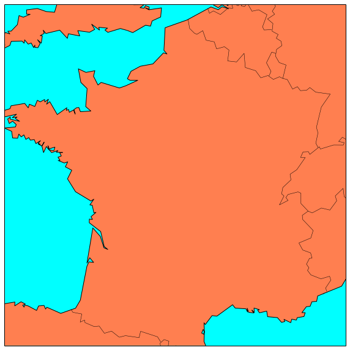

In this post, I present a visualization I use when trying to memorize cell phone numbers: the French "département" trajectory landscape.

[Read more →](http://flothesof.github.io/French-department-trajectories.html)

[Geography](http://flothesof.github.io/tag/geography.html)

## [The Fourier series of a rectangle function](http://flothesof.github.io/Fourier-series-rectangle.html)

Thu, 20 Feb 2014

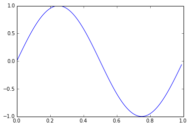

Do you know the Fourier transform? In this post, we plot the Fourier transform of the rectangle function.

[Read more →](http://flothesof.github.io/Fourier-series-rectangle.html)

[Mathematics](http://flothesof.github.io/tag/mathematics.html)

## [Analyzing verb endings in the Japanese language](http://flothesof.github.io/verb-endings-Japanese.html)

Sat, 23 Nov 2013

[Read more →](http://flothesof.github.io/verb-endings-Japanese.html)

[Japanese](http://flothesof.github.io/tag/japanese.html)

## [Creating a shortcut to the IPython Notebook server in the Windows 7 file explorer](http://flothesof.github.io/IPythonNotebook-shortcut-Windows7-explorer.html)

Fri, 22 Nov 2013

[figure not shown]

[Read more →](http://flothesof.github.io/IPythonNotebook-shortcut-Windows7-explorer.html)

[Windows 7](http://flothesof.github.io/tag/windows-7.html) [IPython Notebook](http://flothesof.github.io/tag/ipython-notebook.html)

## [Japan life tables](http://flothesof.github.io/japan-life-tables.html)

Tue, 05 Nov 2013

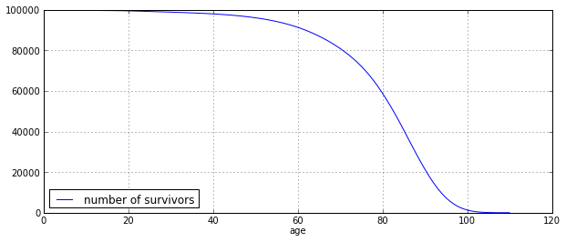

[Read more →](http://flothesof.github.io/japan-life-tables.html)

[Japan](http://flothesof.github.io/tag/japan.html) [statistics](http://flothesof.github.io/tag/statistics.html)

## [A response to falling with helium (Wolfram blog DIY)](http://flothesof.github.io/falling-with-helium.html)

Tue, 08 Oct 2013

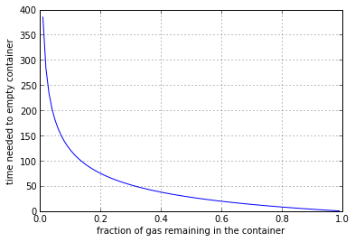

[Read more →](http://flothesof.github.io/falling-with-helium.html)

[Physics](http://flothesof.github.io/tag/physics.html)